# aquaponics microbiome

Demitri

4/3/2020

## Import

get qiime files into R. I use *Phyloseq* to

- clean up irregularites in taxonomy table
- remove ASVs associated with mitochondria and chloroplast
- rename ASV (e.g. ASV1, ASV2, etc.)
- make transformation to ratios
- normalize via rarefaction

```r
library("biomformat")
library("phyloseq")
library("ggplot2")
library("Biostrings")
library("tidyverse")
library("gridExtra")
library("vegan")

tree = "tree.nwk"
map = "meta.txt"
repseq = "dna-sequences.fasta"
biom = read_biom("table-with-taxonomy.biom")
data = import_biom(biom, tree, parseFunction = parse_taxonomy_greengenes)

#update and fix sample_data
meta = import_qiime_sample_data(map)
sample_data(data) = meta

#reference sequences
bs = readDNAStringSet(repseq)
data = merge_phyloseq(data, bs)

#remove mistaken taxanomic ranks
tax_table(data) <- tax_table(data)[, 1:7]

#remove chloroplasts & mitochondria
data = subset_taxa(data, Family != "Mitochondria" & Class != "Chloroplast" & Family != "mitochondria" )

#rename OTU names
taxa_names(data) = paste0("ASV",seq(ntaxa(data)))

#transform abundance to ratio
data_r = transform_sample_counts(data, function(x) 100* x/sum(x))

#rarefy to min. sequence count
rngseed1=100
data_rarefy = rarefy_even_depth(data, sample.size = min(sample_sums(data)), rngseed = rngseed1, replace = TRUE, trimOTUs = TRUE, verbose = TRUE)
data_rarefy_r = transform_sample_counts(data_rarefy, function(x) 100* x/sum(x))
```

```r
sequence_sum = sample_sums(data)
otu_sum = apply(otu_table(data)>0, 2, sum)
sample_info = as.data.frame(cbind(as(sample_data(data), "matrix"), sequence_sum, otu_sum)) %>%
  select(Tank, Type, sequence_sum, otu_sum)%>%
  rename(Sequences = sequence_sum, ASVs = otu_sum)

#reorder rows
slist = paste0(rep("sample-", times = 16), seq.int(1,16), "")
sample_info = sample_info[slist,]
```

There was a total of 296,234 quality filtered reads and 505 ASVs in the data set. The average reads per sample was 18,514.62 The lowest count was 6,983 in sample 10 and the highest was 41,282 in sample 1. An overview of the samples is shown in the following table.

|  | Tank | Type | Sequences | ASVs |
| --- | --- | --- | --- | --- |
| sample-1 | gut | gut | 41282 | 64 |
| sample-2 | gut | gut | 38820 | 72 |
| sample-3 | fish | water | 26779 | 123 |
| sample-4 | fish | water | 26180 | 136 |
| sample-5 | fish | substrate | 11389 | 241 |
| sample-6 | fish | substrate | 13490 | 226 |
| sample-7 | hydroponic | water | 12424 | 251 |
| sample-8 | hydroponic | water | 21972 | 192 |
| sample-9 | hydroponic | substrate | 10080 | 266 |
| sample-10 | hydroponic | substrate | 6983 | 315 |

[output cut: 6 more lines]

## Rarefaction

Rarefaction curves were produced using *vegan* function *rarecurve*. Each curve shows the number of ASVs or bacteria species found in a sample at different sequence counts. As the number of 16S sequences increases, the slope of all curves approach zero. This indicates that the sampling depth was satisfactory and the samples are a fair representation of the bacteria community

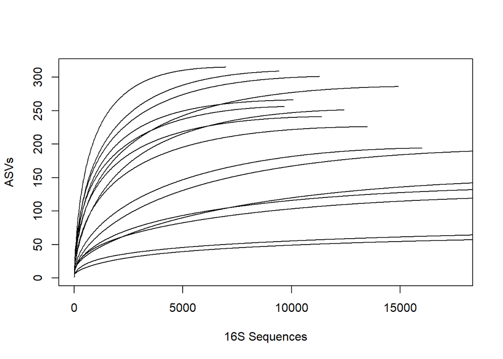

```r
library(vegan)

#function to transpose phyloseq OTU table into vegan OTU matrix
veganotu = function(physeq) {
  require("vegan")
  OTU = otu_table(physeq)
  if (taxa_are_rows(OTU)) {
    OTU = t(OTU)
  }
  return(as(OTU, "matrix"))
}

#transpose phyloseq table to vegan-compatible matrix
rcurve_data = veganotu(data)

#xlimit at median sequences
r = rarecurve(rcurve_data, step = 20, xlab = "16S Sequences", ylab = "ASVs", label = FALSE, xlim = c(0,17633))
```

## Alpha Diversity

Richness and Eveness were used to compare the diversity within samples. Richness refers to the number of ASVs or species and eveness to how they are distrbuted. Pielou’s eveness index
$$J=H/ln(S)$$
was derived using *vegan* function *diversity*.

[figure not shown]

```r
#function to transpose phyloseq OTU table into vegan OTU matrix
veganotu = function(physeq) {
  require("vegan")
  OTU = otu_table(physeq)
  if (taxa_are_rows(OTU)) {
    OTU = t(OTU)
  }
  return(as(OTU, "matrix"))
}

#use rarefied counts
v_data = veganotu(data_rarefy)

#get sum of ASV's for each sample
rich = specnumber(v_data)

#Shannon diversity score
H = diversity(v_data, index = "shannon")

#Pielous's Eveness
J <- H/log(specnumber(v_data))

#make table
x = as.data.frame(cbind(as(sample_data(data), "matrix"), H, J, rich))
x$H = as.numeric(as.character(x$H))
x$J = as.numeric(as.character(x$J))
x$rich = as.numeric(as.character(x$rich))


p = ggplot(x, aes(x = Type, y = rich))+
  geom_boxplot(coef =4, alpha = 0.5)+
  geom_jitter(color = "black", size = 0.6, alpha = 0.9)+
  ylab("Richness")+
  xlab("")

pp = ggplot(x, aes(x = Type, y = H))+
  stat_boxplot(coef = 4, alpha = 0.5)+
  geom_jitter(color = "black", size = 0.6, alpha = 0.9)+
  ylab("Pielous's Evenness")+
  xlab("")
grid.arrange(p,pp, nrow = 1)
```

## Beta Diversity

### Hierarchical cluster analysis

Hierarachcical clustering of Bray-Curtis dissimilarity matrix using Average-linkage method from package *hclust* shows clustering of samples by Type. Substrate samples from the same tank form discrete clusters while water samples are more ambigious.

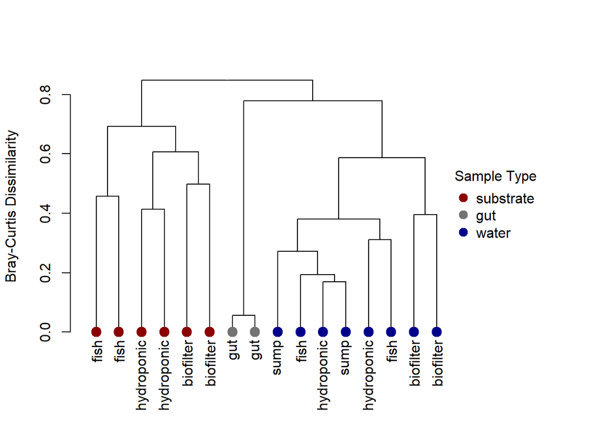

```r
source('C:/Users/dlifg/Desktop/aquaponics sequence data/QIIME files/qiime2/scripts/plot_dendrogram.R')
plot_dendrogram(data_rarefy,"average", "Tank")
```

### Non-metric dimensional scaling (NMDS)

NMDS ordination of Bray-Curtis distance using *vegan* function *metaMDS* with dimensions, k = 5 and stress = 0.012. Ellipses validates hierarchical clustery of samples by Type.

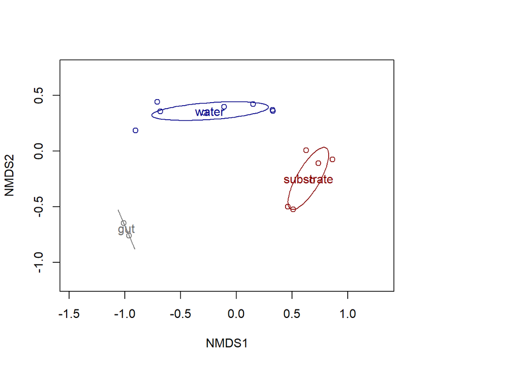

```r
#convert phyloseq sample data into data frame
v_meta = as.data.frame(as.matrix(sample_data(data_rarefy)))

#picked 5 dimenstions (k = 5) as stress
bc.nmds = metaMDS(v_data, distance = "bray", k = 5, trymax = 100)

par(mar=c(5.1, 4.1, 4.1, 8.1), xpd=TRUE)
plot(bc.nmds, type = "n")
points(bc.nmds, display = "sites", col=c("grey45","darkred", "darkblue")[v_meta$Type])
ordiellipse(bc.nmds, groups = v_meta$Type, kind = "se", conf = .99, draw = "lines", col = c("grey45","darkred", "darkblue"), label = TRUE, alpha = 100)
```

```r
#legend("topright", legend = c("gut", "substrate", "water"), col = c("grey45","darkred", "darkblue"),
#       pch=20, inset = c(-0.2,0), title = "Sample Type", y.intersp = 1, x.intersp = 1, bty = "n", pt.cex = 2)
```

### Adonis

```r
doadonis <- function(physeq, category, distance) {
  bdist <- phyloseq::distance(physeq, distance)
  col <- as(sample_data(physeq), "data.frame")[ ,category]

  # Adonis test -- do the centroid differ according to category (i.e sampele type)
  adonis.bdist <- adonis(bdist ~ col)
  print("Adonis results:")
  print(adonis.bdist)

  # Homogeneity of dispersion test -- does the variance of the communties differ according to category (i.e. sample type)
  betatax = betadisper(bdist,col)
  p = permutest(betatax)
  print("Betadisper results:")
  print(p$tab)
}

doadonis(data_rarefy, "Type", "bray")
```

```
## [1] "Adonis results:"
##
## Call:
## adonis(formula = bdist ~ col)
##
## Permutation: free
## Number of permutations: 999
##
## Terms added sequentially (first to last)
##
##           Df SumsOfSqs MeanSqs F.Model      R2 Pr(>F)
## col        2    2.3495 1.17475  8.7922 0.57495  0.001 ***
## Residuals 13    1.7370 0.13361         0.42505
## Total     15    4.0865                 1.00000
## ---
## Signif. codes:  0 '***' 0.001 '**' 0.01 '*' 0.05 '.' 0.1 ' ' 1
## [1] "Betadisper results:"
##           Df    Sum Sq   Mean Sq        F N.Perm Pr(>F)
## Groups     2 0.2151814 0.1075907 9.150813    999  0.006
## Residuals 13 0.1528475 0.0117575       NA     NA     NA
```

## Composition

### Phylum-level

Bar plots showing the abundance of phyla was generated in *ggplot*. Any phyla contributing less than 1% of total abundance in any one sample were grouped together in category: **<1%**.

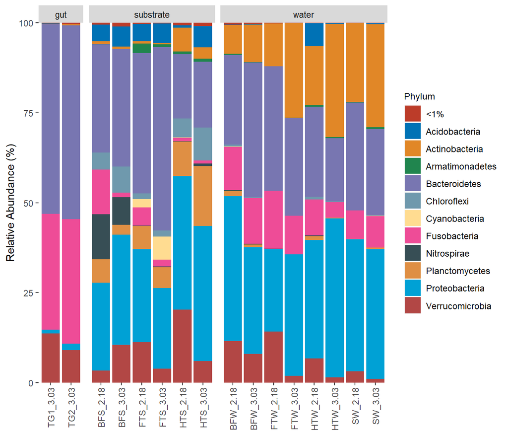

```r
source('C:/Users/dlifg/Desktop/aquaponics sequence data/QIIME files/qiime2/scripts/plot_phylum.R')
plot_phylum(data_rarefy_r)
```

In total, 15 different phyla were identified with 11 contributing over 99% of the abundance in any given sample. Bacteriodetes, Proteobacteria, Fusobacteria, Verrucomicrobia, and Actinobacteria were the most prevelant in all samples but differences were seen in the different environment types. Proteobacteria made up only 1%-2% of the gut community but were enriched in water and substrate environments making up between 22% - 44% of the community. Actinobacteria was prevelent in the water environment (19% average abundance) but much less so in substrate enivornment (2% average abundance). Planctomycetes, Chlorflexi, and Acidobacteria on the other hand were more prevelant in the substrate environment. Only Nitrospirae showed any tank specific localization, as it was only prevelant in the biofilter substrate site.

### ASV-level

Heatmat generated with *heatmap.2* shows the general composition of the system. Only ASV’s making up at least 1% of the abundance in any single sample are included. Samples (columns) are ordered by clustering of Bray-Curtis dissimilarity of the samples entire community. ASVs (rows) are ordered by Euclidean distance based clustering. Phylum and the highest taxonomic level is shown for each ASV. The number in brackets indicate the number of ASVs with identical taxonomy.

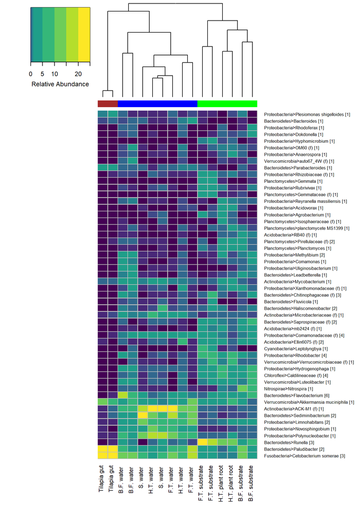

```r
source('C:/Users/dlifg/Desktop/aquaponics sequence data/QIIME files/qiime2/scripts/ASV_heatmap.R')
hmap(data_rarefy_r,1)
```

## ASV’s driving the the dissimlarity between aquaponic environments

### Method 1: DESeq2 differential abundance

*DESeq2* package provides methods to test for differential expression by use of negative binomial models. Orignally implemented for RNA-Seq, it has been adopted for microbiome analyses in *phyloseq*. I followed this phyloseq tutorial: https://bioconductor.org/packages/devel/bioc/vignettes/phyloseq/inst/doc/phyloseq-mixture-models.html

```r
library(DESeq2)

#use unrarefied data
#remove gut samples because I'm intersted in difference between water and substrate environment
#low number of gut samples could skew test
data_noGut = subset_samples(data, Type != "gut")

#convert to deseq2 class using Type as study design factor. Type refers to either water or substrate
data_deseq = phyloseq_to_deseq2(data_noGut, ~ Type)

#calculate modified geometric means that ignores zeroes.
gm_mean = function(x, na.rm=TRUE){
  exp(sum(log(x[x > 0]), na.rm=na.rm) / length(x))
}
geoMeans = apply(counts(data_deseq), 1, gm_mean)

#calculate normalize factors using modified geometric means
data_deseq = estimateSizeFactors(data_deseq, geoMeans = geoMeans)

#performs differential expression based on the negative binomial distribution. Used default test (Wald). fitType = "local" for dispersion estimates
data_deseq = DESeq(data_deseq, fitType="local")

#get results of test
res = results(data_deseq, cooksCutoff = FALSE)
res = res[order(res$padj, na.last=NA), ]

#select for P value <0.01
alpha = 0.01
sigtab = res[(res$padj < alpha), ]

#add taxonmy to results table
sigtab = cbind(as(sigtab, "data.frame"), as(tax_table(data_noGut)[rownames(sigtab), ], "matrix"))
sigtab = sigtab[, c("baseMean", "log2FoldChange", "padj", "Phylum", "Class", "Family", "Genus", "Species")]
```

|  | baseMean | log2FoldChange | padj | Phylum | Class | Family | Genus | Species |
| --- | --- | --- | --- | --- | --- | --- | --- | --- |
| ASV157 | 2617.664487 | 8.233362 | 8.632552e-29 | Actinobacteria | Actinobacteria | ACK-M1 | NA | NA |
| ASV410 | 918.293222 | 8.099315 | 9.860075e-27 | Proteobacteria | Alphaproteobacteria | Sphingomonadaceae | Novosphingobium | NA |
| ASV299 | 1834.820190 | 8.424229 | 1.310292e-26 | Bacteroidetes | [Saprospirae] | Chitinophagaceae | Sediminibacterium | NA |
| ASV200 | 1255.369250 | 7.827755 | 2.223340e-21 | Proteobacteria | Betaproteobacteria | Comamonadaceae | Limnohabitans | NA |
| ASV257 | 1677.152268 | 6.525668 | 1.544832e-19 | Proteobacteria | Betaproteobacteria | Oxalobacteraceae | Polynucleobacter | NA |
| ASV202 | 248.410283 | 8.294297 | 3.043248e-15 | Proteobacteria | Betaproteobacteria | Comamonadaceae | NA | NA |
| ASV300 | 148.726142 | 8.577783 | 2.474554e-12 | Bacteroidetes | [Saprospirae] | Chitinophagaceae | Sediminibacterium | NA |
| ASV163 | 359.151782 | 5.798812 | 7.056629e-12 | Actinobacteria | Actinobacteria | Microbacteriaceae | NA | NA |
| ASV276 | 39.584795 | 8.943767 | 9.571696e-12 | Proteobacteria | Gammaproteobacteria | Xanthomonadaceae | NA | NA |
| ASV140 | 52.651007 | -5.894714 | 3.257163e-11 | Acidobacteria | Acidobacteria-6 | mb2424 | NA | NA |

[output cut: 46 more lines]

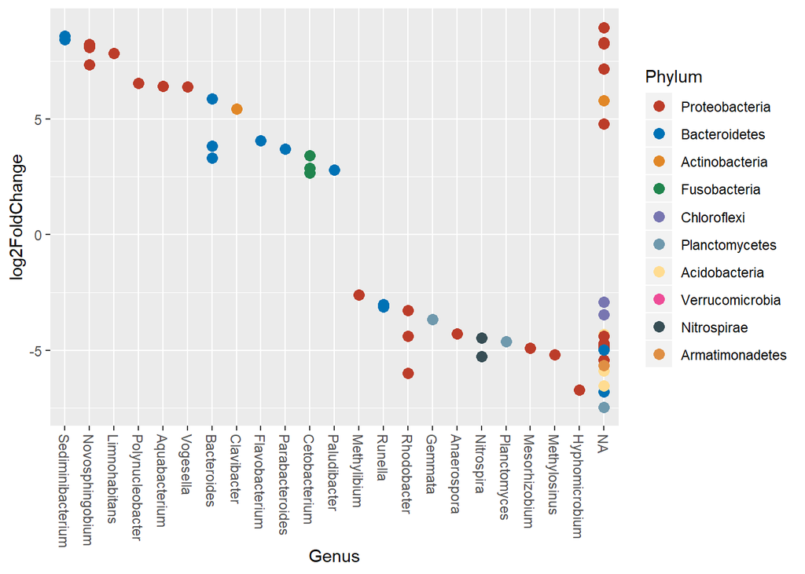

```r
# Phylum order
x = tapply(sigtab$log2FoldChange, sigtab$Phylum, function(x) max(x))
x = sort(x, TRUE)
sigtab$Phylum = factor(as.character(sigtab$Phylum), levels=names(x))
# Genus order
x = tapply(sigtab$log2FoldChange, sigtab$Genus, function(x) max(x))
x = sort(x, TRUE)
sigtab$Genus = factor(as.character(sigtab$Genus), levels=names(x))
#plot
ggplot(sigtab, aes(x=Genus, y=log2FoldChange, color=Phylum)) + geom_point(size=3) +
  theme(axis.text.x = element_text(angle = -90, hjust = 0, vjust=0.5))+
  scale_color_manual(values = phylum_colors2)
```

### Method 2: SIMPER

```r
#used on
simp = simper(v_data, v_meta$Type, permutations=100)
simp_sum = summary(simp)

water_substrate = simp_sum$water_substrate[1:10,]
water_substrate =  cbind(water_substrate, as(tax_table(data)[rownames(water_substrate), ], "matrix"))
```

|  | average | sd | ratio | ava | avb | cumsum | p | Kingdom | Phylum | Class | Order | Family | Genus | Species |
| --- | --- | --- | --- | --- | --- | --- | --- | --- | --- | --- | --- | --- | --- | --- |
| ASV157 | 0.07765585 | 0.037262564 | 2.0840180 | 1097.375 | 12.833333 | 0.09305809 | 0.01980198 | Bacteria | Actinobacteria | Actinobacteria | Actinomycetales | ACK-M1 | NA | NA |
| ASV326 | 0.05309621 | 0.054050241 | 0.9823492 | 42.750 | 783.666667 | 0.15668539 | 0.00990099 | Bacteria | Bacteroidetes | Cytophagia | Cytophagales | Cytophagaceae | Runella | NA |
| ASV299 | 0.05155974 | 0.031092853 | 1.6582505 | 727.750 | 7.666667 | 0.21847147 | 0.01980198 | Bacteria | Bacteroidetes | [Saprospirae] | [Saprospirales] | Chitinophagaceae | Sediminibacterium | NA |
| ASV257 | 0.05066173 | 0.024049421 | 2.1065674 | 735.875 | 28.333333 | 0.27918143 | 0.00990099 | Bacteria | Proteobacteria | Betaproteobacteria | Burkholderiales | Oxalobacteraceae | Polynucleobacter | NA |
| ASV200 | 0.03847737 | 0.018430751 | 2.0876726 | 543.375 | 6.000000 | 0.32529039 | 0.00990099 | Bacteria | Proteobacteria | Betaproteobacteria | Burkholderiales | Comamonadaceae | Limnohabitans | NA |
| ASV410 | 0.02646009 | 0.017532797 | 1.5091769 | 374.375 | 4.833333 | 0.35699857 | 0.01980198 | Bacteria | Proteobacteria | Alphaproteobacteria | Sphingomonadales | Sphingomonadaceae | Novosphingobium | NA |
| ASV383 | 0.02566948 | 0.017347703 | 1.4797050 | 453.875 | 192.833333 | 0.38775933 | 1.00000000 | Bacteria | Bacteroidetes | Bacteroidia | Bacteroidales | Porphyromonadaceae | Paludibacter | NA |
| ASV34 | 0.01750680 | 0.017933358 | 0.9762144 | 295.750 | 199.333333 | 0.40873843 | 0.99009901 | Bacteria | Verrucomicrobia | Verrucomicrobiae | Verrucomicrobiales | Verrucomicrobiaceae | Akkermansia | muciniphila |
| ASV327 | 0.01674901 | 0.014217639 | 1.1780444 | 15.250 | 249.166667 | 0.42880943 | 0.00990099 | Bacteria | Bacteroidetes | Cytophagia | Cytophagales | Cytophagaceae | Runella | NA |
| ASV198 | 0.01650437 | 0.008245423 | 2.0016398 | 55.625 | 278.333333 | 0.44858727 | 0.01980198 | Bacteria | Proteobacteria | Betaproteobacteria | Burkholderiales | Comamonadaceae | Hydrogenophaga | NA |

Bartelme, Ryan P., Matthew C. Smith, Osvaldo J. Sepulveda-Villet, and Ryan J. Newton. 2019. “Component Microenvironments and System Biogeography Structure Microorganism Distributions in Recirculating Aquaculture and Aquaponic Systems.” *mSphere* 4 (4): 1–15. https://doi.org/10.1128/msphere.00143-19.

Schmautz, Zala, Andreas Graber, Sebastian Jaenicke, Alexander Goesmann, Ranka Junge, and Theo H M Smits. 2017. “Microbial diversity in different compartments of an aquaponics system.” *Archives of Microbiology* 0. https://doi.org/10.1007/s00203-016-1334-1.

Tsuchiya, C., T. Sakata, and H. Sugita. 2008. “Novel ecological niche of Cetobacterium somerae, an anaerobic bacterium in the intestinal tracts of freshwater fish.” *Letters in Applied Microbiology* 46 (1): 43–48. https://doi.org/10.1111/j.1472-765X.2007.02258.x.

Zwart, Gabriel, Byron C. Crump, Miranda P. Kamst-van Agterveld, Ferry Hagen, and Suk Kyun Han. 2002. “Typical freshwater bacteria: An analysis of available 16S rRNA gene sequences from plankton of lakes and rivers.” *Aquatic Microbial Ecology* 28 (2): 141–55. https://doi.org/10.3354/ame028141.